# Example4

### Generalized Additive Model

#### scaling data 사용

```r
mm <- gam(TC~s(pH)+s(DO)+s(BOD)+s(COD)+s(SS)+s(TN)+s(TP)+s(TOC)+s(WT)+s(EC)+s(Chla)+s(NH3N)+s(PO4P)+s(FC)+s(Flow)+s(Rain),data=ex2_scale)
ggGam(mm)
```

```
##  chr "ggGam(model = mm)"
## List of 1
##  $ model: chr "mm"
```

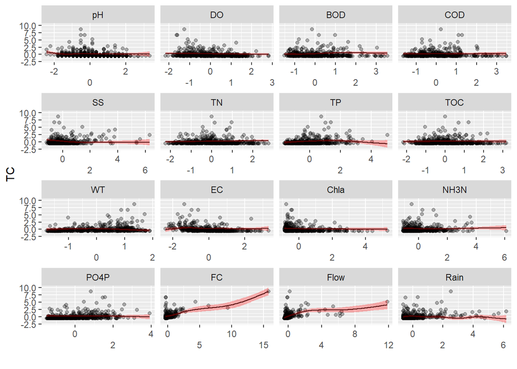

```r
summary(mm) # R-sq.(adj) =  0.577
```

```
##
## Family: gaussian
## Link function: identity
##
## Formula:
## TC ~ s(pH) + s(DO) + s(BOD) + s(COD) + s(SS) + s(TN) + s(TP) +
##     s(TOC) + s(WT) + s(EC) + s(Chla) + s(NH3N) + s(PO4P) + s(FC) +
##     s(Flow) + s(Rain)
##
## Parametric coefficients:
##               Estimate Std. Error t value Pr(>|t|)
## (Intercept) -5.492e-13  2.877e-02       0        1
##
## Approximate significance of smooth terms:
##           edf Ref.df      F  p-value
## s(pH)   5.599  6.680  1.360 0.217149
## s(DO)   1.000  1.000  1.168 0.280347
## s(BOD)  3.481  4.302  2.898 0.021167 *
## s(COD)  1.000  1.000  0.012 0.913225
## s(SS)   3.104  3.854  5.665 0.000282 ***
## s(TN)   1.000  1.000  2.099 0.148116
## s(TP)   3.654  4.565  2.850 0.018745 *
## s(TOC)  1.446  1.779  0.342 0.629061
## s(WT)   3.138  3.937  4.060 0.003313 **
## s(EC)   5.442  6.609  2.000 0.063203 .
## s(Chla) 1.000  1.000  0.448 0.503398
## s(NH3N) 2.129  2.730  1.663 0.211692
## s(PO4P) 2.592  3.300  0.696 0.582616
## s(FC)   3.895  4.645 49.896  < 2e-16 ***
## s(Flow) 3.686  4.425 17.640  < 2e-16 ***
## s(Rain) 6.508  7.587  1.782 0.084857 .
## ---
## Signif. codes:  0 '***' 0.001 '**' 0.01 '*' 0.05 '.' 0.1 ' ' 1
##
## R-sq.(adj) =  0.577   Deviance explained = 61.7%
## GCV = 0.46852  Scale est. = 0.42298   n = 511
```

```r
concurvity(mm,full=TRUE) # 공선성 존재
```

```
##                para     s(pH)     s(DO)    s(BOD)    s(COD)     s(SS)     s(TN)
## worst    4.9079e-18 0.7733657 0.8305237 0.8622507 0.9177868 0.9775793 0.8068857
## observed 4.9079e-18 0.3152725 0.8126589 0.8071483 0.9092605 0.8039834 0.7788238
## estimate 4.9079e-18 0.5336426 0.7299106 0.7711967 0.8711572 0.6949004 0.6870464
##              s(TP)    s(TOC)     s(WT)     s(EC)   s(Chla)   s(NH3N)   s(PO4P)
## worst    0.9754376 0.8945658 0.9168842 0.8036826 0.8479082 0.6748301 0.7913130
## observed 0.7615479 0.8044911 0.6837580 0.5529718 0.8168838 0.5953224 0.6021765
## estimate 0.7368539 0.8254274 0.8572541 0.6511063 0.7020812 0.5175593 0.7103594
##              s(FC)   s(Flow)   s(Rain)
## worst    0.9927452 0.9927597 0.7813211
## observed 0.4018682 0.8415552 0.6030873
## estimate 0.3330150 0.8734198 0.6689192
```

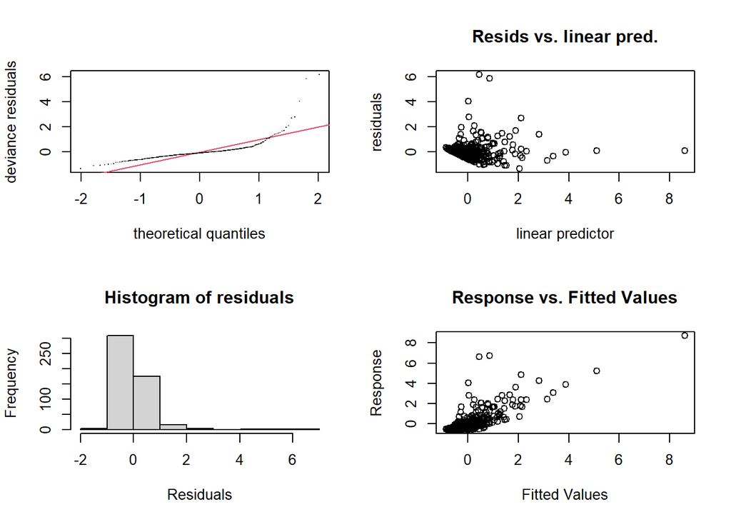

```
##
## Method: GCV   Optimizer: magic
## Smoothing parameter selection converged after 15 iterations.
## The RMS GCV score gradient at convergence was 1.498805e-08 .
## The Hessian was positive definite.
## Model rank =  145 / 145
##
## Basis dimension (k) checking results. Low p-value (k-index<1) may
## indicate that k is too low, especially if edf is close to k'.
##
##           k'  edf k-index p-value
## s(pH)   9.00 5.60    0.91    0.05 *
## s(DO)   9.00 1.00    1.05    0.94
## s(BOD)  9.00 3.48    0.94    0.06 .
## s(COD)  9.00 1.00    1.00    0.44
## s(SS)   9.00 3.10    0.99    0.26
## s(TN)   9.00 1.00    0.98    0.22
## s(TP)   9.00 3.65    1.01    0.53
## s(TOC)  9.00 1.45    0.96    0.15
## s(WT)   9.00 3.14    0.99    0.42
## s(EC)   9.00 5.44    1.00    0.49
## s(Chla) 9.00 1.00    0.97    0.20
## s(NH3N) 9.00 2.13    1.04    0.82
## s(PO4P) 9.00 2.59    0.99    0.37
## s(FC)   9.00 3.90    0.97    0.19
## s(Flow) 9.00 3.69    1.00    0.40
## s(Rain) 9.00 6.51    1.04    0.80
## ---
## Signif. codes:  0 '***' 0.001 '**' 0.01 '*' 0.05 '.' 0.1 ' ' 1
```

```r
par(mfrow=c(2,2))
gam.check(mm) # 적합결여 존재 (기저함수 부족)
```

```r
par(mfrow=c(1,1))
mm1 <- gam(TC~s(BOD)+s(SS)+s(TP)+s(WT)+s(FC)+s(Flow),data=ex2_scale) # 모형 mm에서 유의하지 않은 변수를 제외하고 모형구축.
ggGam(mm1)
```

```
##  chr "ggGam(model = mm1)"
## List of 1
##  $ model: chr "mm1"
```

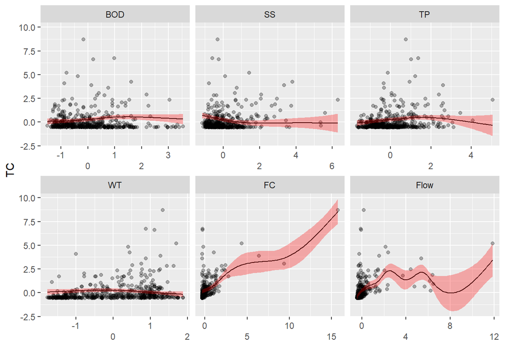

```r
summary(mm1) # R-sq.(adj) =  0.558
```

```
##
## Family: gaussian
## Link function: identity
##
## Formula:
## TC ~ s(BOD) + s(SS) + s(TP) + s(WT) + s(FC) + s(Flow)
##
## Parametric coefficients:
##               Estimate Std. Error t value Pr(>|t|)
## (Intercept) -1.401e-15  2.942e-02       0        1
##
## Approximate significance of smooth terms:
##           edf Ref.df      F  p-value
## s(BOD)  3.168  3.932  3.484 0.007396 **
## s(SS)   2.874  3.593  5.404 0.000658 ***
## s(TP)   3.196  4.029  4.186 0.002307 **
## s(WT)   2.399  3.022  3.776 0.010404 *
## s(FC)   4.522  5.367 44.830  < 2e-16 ***
## s(Flow) 7.976  8.687 11.863  < 2e-16 ***
## ---
## Signif. codes:  0 '***' 0.001 '**' 0.01 '*' 0.05 '.' 0.1 ' ' 1
##
## R-sq.(adj) =  0.558   Deviance explained = 57.9%
## GCV = 0.46515  Scale est. = 0.44227   n = 511
```

```r
concurvity(mm1,full=TRUE) # 공선성 존재
```

```
##                  para    s(BOD)     s(SS)     s(TP)     s(WT)     s(FC)
## worst    1.483826e-22 0.6888594 0.9656917 0.9632843 0.4667149 0.9903192
## observed 1.483826e-22 0.6261872 0.7308244 0.4493027 0.2616935 0.2364285
## estimate 1.483826e-22 0.5480886 0.5840396 0.5185872 0.3906416 0.1508238
##            s(Flow)
## worst    0.9903039
## observed 0.6852659
## estimate 0.7184709
```

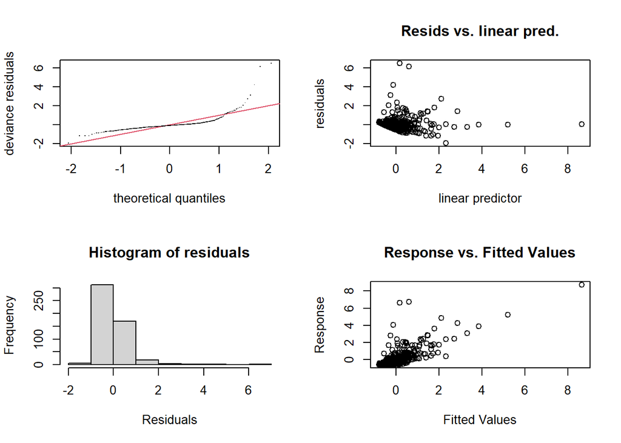

```
##
## Method: GCV   Optimizer: magic
## Smoothing parameter selection converged after 11 iterations.
## The RMS GCV score gradient at convergence was 6.198362e-08 .
## The Hessian was positive definite.
## Model rank =  55 / 55
##
## Basis dimension (k) checking results. Low p-value (k-index<1) may
## indicate that k is too low, especially if edf is close to k'.
##
##           k'  edf k-index p-value
## s(BOD)  9.00 3.17    0.92    0.03 *
## s(SS)   9.00 2.87    1.00    0.37
## s(TP)   9.00 3.20    1.00    0.45
## s(WT)   9.00 2.40    1.02    0.59
## s(FC)   9.00 4.52    0.95    0.15
## s(Flow) 9.00 7.98    1.00    0.40
## ---
## Signif. codes:  0 '***' 0.001 '**' 0.01 '*' 0.05 '.' 0.1 ' ' 1
```

```r
par(mfrow=c(2,2))
gam.check(mm1) # 적합결여 존재 (기저함수 부족)
```

```r
par(mfrow=c(1,1))
```

### Time Varying Coefficient Model

#### scaling data 사용

```r
par(mar=c(4,4,4,4))
par(oma=c(0.5,0.5,0.5,0.5))
nrow(ex2_scale)
```

```
## [1] 511
```

```r
ex2_scale$time <- 1:nrow(ex2_scale)
head(ex2_scale)
```

```
##            pH        DO         BOD        COD         SS       TN          TP
## 1 -0.93716819 1.0893800 -0.58575074 -1.3453204 -1.0140482 1.980445 -0.64266981
## 2 -0.51261770 1.5901355 -1.01304357 -1.2114347 -0.8538304 1.606223 -0.59069477
## 3 -1.36171867 1.2980281  0.34005039 -0.8544060 -0.6592803 1.834562 -0.09693192
## 4 -0.08806722 0.8807319 -0.51453527 -0.7205202 -0.6821685 1.086118 -0.64266981
## 5 -0.08806722 1.2562985 -0.58575074 -0.9882917 -0.7851657 1.046475 -0.69464485
## 6 -0.72489295 1.3814873 -0.08724244 -0.6312631 -0.7165009 1.752106 -0.25285703
##          TOC        WT        EC          TC      NH3N       PO4P       Chla
## 1 -1.3280643 -1.489617 0.5356084 -0.27362350 0.3426390 0.29025953 -0.7228834
## 2 -1.0977628 -1.607883 1.0322439 -0.34948431 0.3791386 0.33192319 -0.7186387
## 3 -1.0401874 -1.607883 0.3742018 -0.22621050 1.8172223 0.91521440 -0.6210099
## 4 -0.5795845 -1.253085 1.0694916 -0.29258870 0.6419356 0.12360490 -0.3620813
## 5 -1.0401874 -1.134820 0.6597673 -0.02707589 0.1674410 0.08194124 -0.7313729
## 6 -0.6947352 -1.489617 0.1134681 -0.23569310 1.0215313 0.79022342 -0.7695755
##           FC       Flow       Rain time
## 1 -0.3032294 -0.3733651 -0.4038260    1
## 2 -0.3254468 -0.3811804 -0.5212748    2
## 3 -0.3024633 -0.3785186 -0.3353142    3
## 4 -0.2733509 -0.3495793 -0.3377611    4
## 5 -0.1894610 -0.3662860 -0.4405288    5
## 6 -0.2162751 -0.2998558  0.4501246    6
```

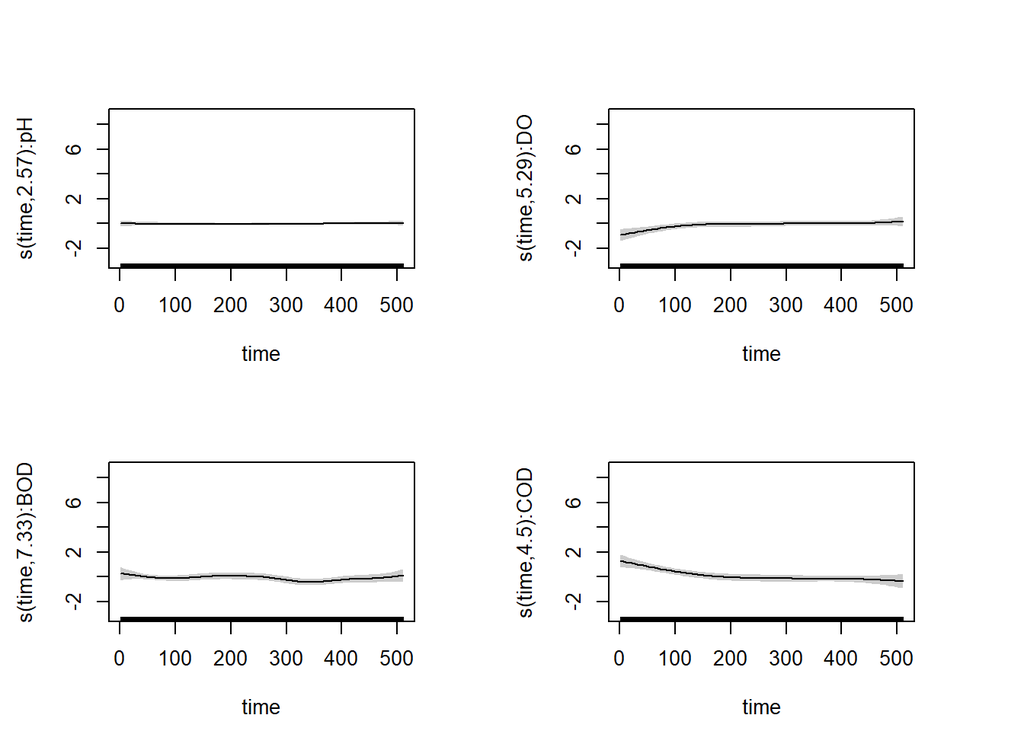

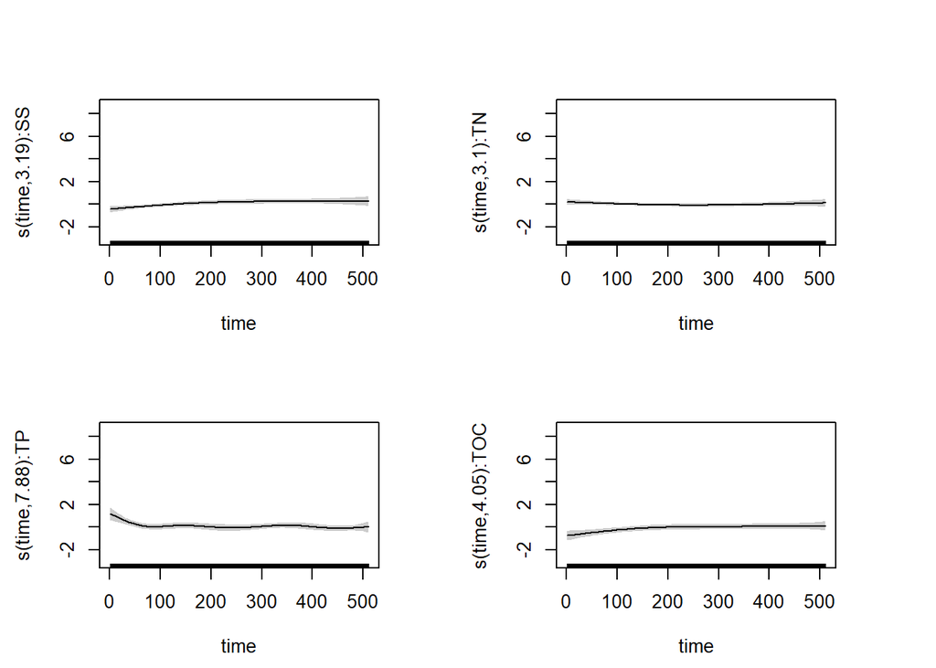

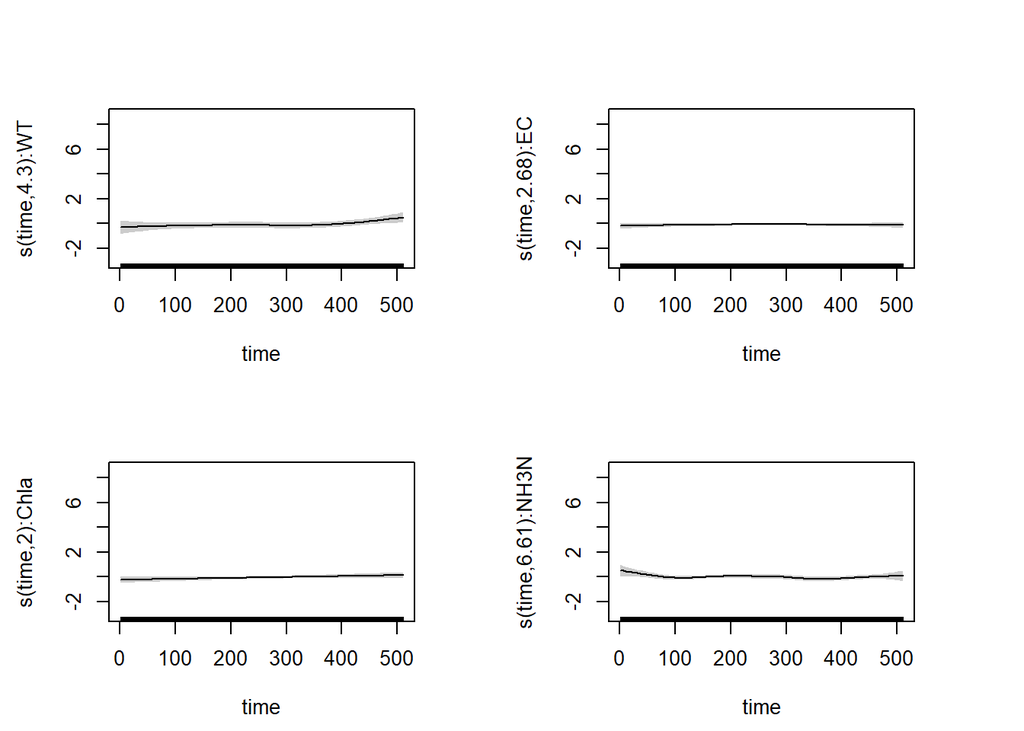

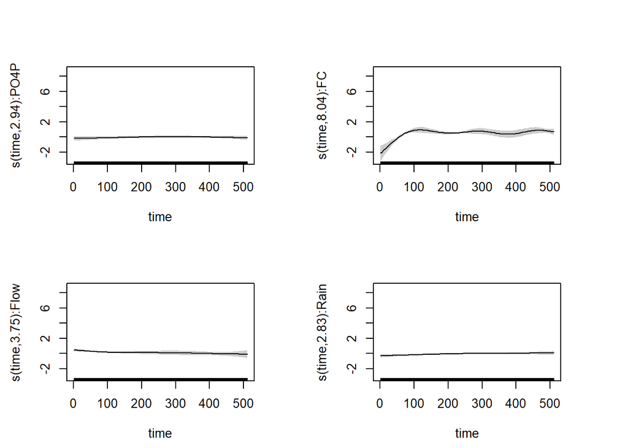

```r
vc1 <- gam(TC~s(time,by=pH)+s(time,by=DO)+s(time,by=BOD)+s(time,by=COD)+s(time,by=SS)+s(time,by=TN)+s(time,by=TP)+s(time,by=TOC)+s(time,by=WT)+s(time,by=EC)+s(time,by=Chla)+s(time,by=NH3N)+s(time,by=PO4P)+s(time,by=FC)+s(time,by=Flow)+s(time,by=Rain),data=ex2_scale)
par(mfrow=c(2,2))
plot(vc1,residuals=TRUE,pch=1,shade=TRUE,seWithMean=TRUE,shift=coef(vc1)[1])
```

```r
par(mfrow=c(1,1))
summary(vc1) # R-sq.(adj) =  0.666
```

```
##
## Family: gaussian
## Link function: identity
##
## Formula:
## TC ~ s(time, by = pH) + s(time, by = DO) + s(time, by = BOD) +
##     s(time, by = COD) + s(time, by = SS) + s(time, by = TN) +
##     s(time, by = TP) + s(time, by = TOC) + s(time, by = WT) +
##     s(time, by = EC) + s(time, by = Chla) + s(time, by = NH3N) +
##     s(time, by = PO4P) + s(time, by = FC) + s(time, by = Flow) +
##     s(time, by = Rain)
##
## Parametric coefficients:
##             Estimate Std. Error t value Pr(>|t|)
## (Intercept) -0.02688    0.03752  -0.716    0.474
##
## Approximate significance of smooth terms:
##                edf Ref.df      F  p-value
## s(time):pH   2.573  2.934  0.196  0.87516
## s(time):DO   5.287  6.199  2.767  0.01015 *
## s(time):BOD  7.334  8.364  1.486  0.13911
## s(time):COD  4.499  5.258  6.466 6.12e-06 ***
## s(time):SS   3.190  3.701  5.141  0.00141 **
## s(time):TN   3.100  3.577  1.467  0.26797
## s(time):TP   7.880  8.775  2.991  0.00206 **
## s(time):TOC  4.047  4.706  2.687  0.01779 *
## s(time):WT   4.303  5.045  1.772  0.11644
## s(time):EC   2.679  3.077  1.559  0.19269
## s(time):Chla 2.000  2.000  1.790  0.16816
## s(time):NH3N 6.607  7.664  1.390  0.21365
## s(time):PO4P 2.939  3.396  0.874  0.53201
## s(time):FC   8.038  8.970 41.732  < 2e-16 ***
## s(time):Flow 3.751  4.347  9.780 2.73e-07 ***
## s(time):Rain 2.835  3.276  3.268  0.01847 *
## ---
## Signif. codes:  0 '***' 0.001 '**' 0.01 '*' 0.05 '.' 0.1 ' ' 1
##
## R-sq.(adj) =  0.666   Deviance explained = 71.2%
## GCV = 0.38938  Scale est. = 0.33447   n = 511
```

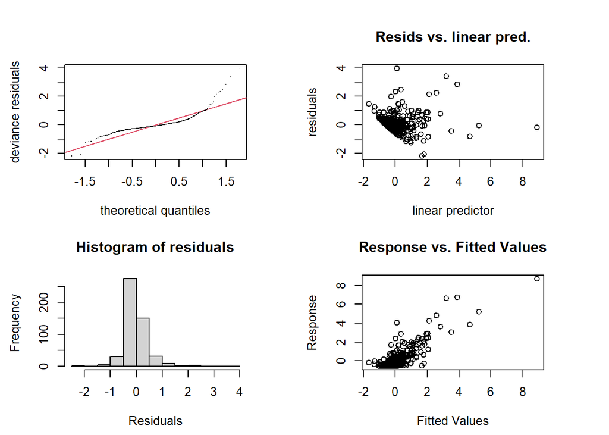

```
##
## Method: GCV   Optimizer: magic
## Smoothing parameter selection converged after 31 iterations.
## The RMS GCV score gradient at convergence was 1.970999e-07 .
## The Hessian was positive definite.
## Model rank =  161 / 161
##
## Basis dimension (k) checking results. Low p-value (k-index<1) may
## indicate that k is too low, especially if edf is close to k'.
##
##                 k'   edf k-index p-value
## s(time):pH   10.00  2.57    0.94   0.095 .
## s(time):DO   10.00  5.29    0.94   0.075 .
## s(time):BOD  10.00  7.33    0.94   0.105
## s(time):COD  10.00  4.50    0.94   0.110
## s(time):SS   10.00  3.19    0.94   0.115
## s(time):TN   10.00  3.10    0.94   0.110
## s(time):TP   10.00  7.88    0.94   0.085 .
## s(time):TOC  10.00  4.05    0.94   0.100 .
## s(time):WT   10.00  4.30    0.94   0.080 .
## s(time):EC   10.00  2.68    0.94   0.090 .
## s(time):Chla 10.00  2.00    0.94   0.080 .
## s(time):NH3N 10.00  6.61    0.94   0.085 .
## s(time):PO4P 10.00  2.94    0.94   0.075 .
## s(time):FC   10.00  8.04    0.94   0.105
## s(time):Flow 10.00  3.75    0.94   0.090 .
## s(time):Rain 10.00  2.83    0.94   0.105
## ---
## Signif. codes:  0 '***' 0.001 '**' 0.01 '*' 0.05 '.' 0.1 ' ' 1
```

```r
par(mfrow=c(2,2))
gam.check(vc1)
```

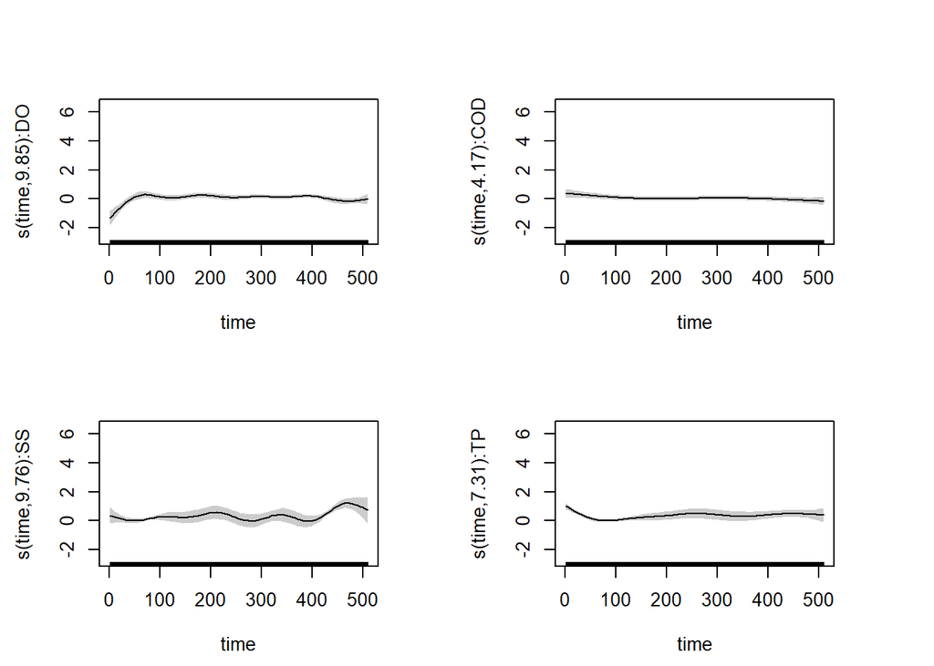

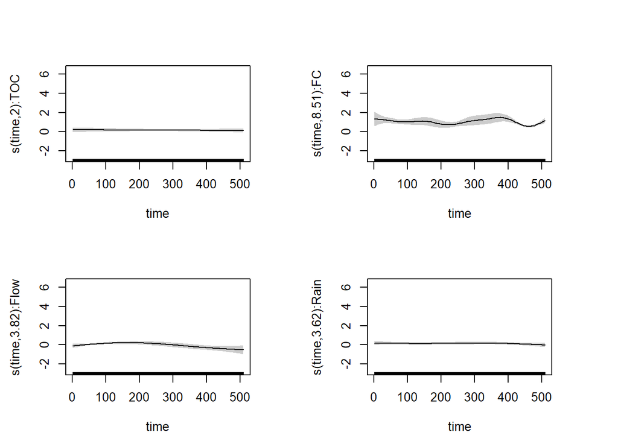

```r
par(mfrow=c(1,1))
vc2 <- gam(TC~s(time,by=DO)+s(time,by=COD)+s(time,by=SS)+s(time,by=TP)+s(time,by=TOC)+s(time,by=FC)+s(time,by=Flow)+s(time,by=Rain),data=ex1_scale) # vc1 모형에서 유의하지 않다고 나온 변수 제외
par(mfrow=c(2,2))
plot(vc2,residuals=TRUE,pch=1,shade=TRUE,seWithMean=TRUE,shift=coef(vc2)[1])
```

```r
par(mfrow=c(1,1))
summary(vc2) # R-sq.(adj) =  0.738
```

```
##
## Family: gaussian
## Link function: identity
##
## Formula:
## TC ~ s(time, by = DO) + s(time, by = COD) + s(time, by = SS) +
##     s(time, by = TP) + s(time, by = TOC) + s(time, by = FC) +
##     s(time, by = Flow) + s(time, by = Rain)
##
## Parametric coefficients:
##             Estimate Std. Error t value Pr(>|t|)
## (Intercept)   0.1130     0.0471   2.399   0.0169 *
## ---
## Signif. codes:  0 '***' 0.001 '**' 0.01 '*' 0.05 '.' 0.1 ' ' 1
##
## Approximate significance of smooth terms:
##                edf Ref.df      F  p-value
## s(time):DO   9.854  9.985  4.221  1.3e-05 ***
## s(time):COD  4.174  4.911  2.441 0.043638 *
## s(time):SS   9.763  9.952  6.169  < 2e-16 ***
## s(time):TP   7.306  8.318 12.046  < 2e-16 ***
## s(time):TOC  2.000  2.000  0.315 0.729724
## s(time):FC   8.505  9.351 51.683  < 2e-16 ***
## s(time):Flow 3.825  4.476  5.048 0.000378 ***
## s(time):Rain 3.618  4.240  0.645 0.670513
## ---
## Signif. codes:  0 '***' 0.001 '**' 0.01 '*' 0.05 '.' 0.1 ' ' 1
##
## R-sq.(adj) =  0.738   Deviance explained = 76.3%
## GCV = 0.29065  Scale est. = 0.26213   n = 510
```

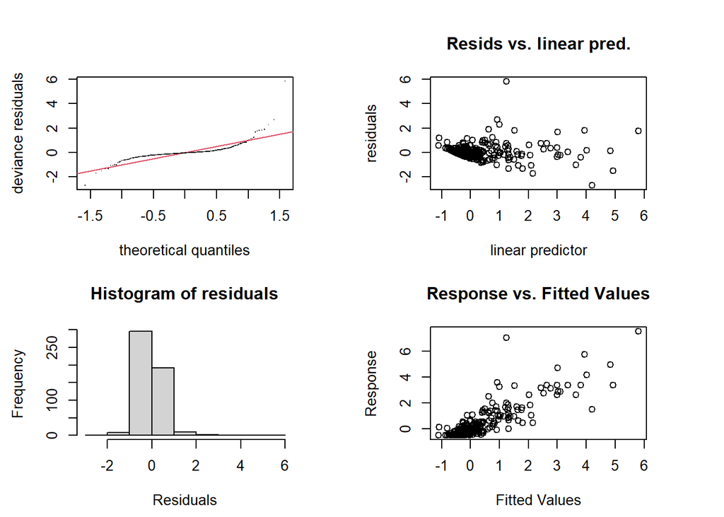

```
##
## Method: GCV   Optimizer: magic
## Smoothing parameter selection converged after 28 iterations.
## The RMS GCV score gradient at convergence was 7.040906e-08 .
## The Hessian was positive definite.
## Model rank =  81 / 81
##
## Basis dimension (k) checking results. Low p-value (k-index<1) may
## indicate that k is too low, especially if edf is close to k'.
##
##                 k'   edf k-index p-value
## s(time):DO   10.00  9.85       1    0.45
## s(time):COD  10.00  4.17       1    0.38
## s(time):SS   10.00  9.76       1    0.46
## s(time):TP   10.00  7.31       1    0.41
## s(time):TOC  10.00  2.00       1    0.43
## s(time):FC   10.00  8.51       1    0.46
## s(time):Flow 10.00  3.82       1    0.41
## s(time):Rain 10.00  3.62       1    0.47
```

```r
par(mfrow=c(2,2))
gam.check(vc2)
```

```r
par(mfrow=c(1,1)) # TOC와 Rain이 유의하지 않게 나왔지만, 이 두 변수를 제외할 경우 추정해야 할 모수의 개수나 이항연산자의 오류 등으로 인하여 모형이 적합되지 않으므로 vc2를 최종모형으로 선정
```

#### 최종선택된 모형의 설명력 : 48.1%(다중선형회귀모형), 55.8%(일반화가법모형), 73.8%(시간에 따른 계수변화모형)

#### 일반화가법모형이나 시간에 따른 계수변화모형이 다중선형회귀모형보다 설명력이 우수하다는 것을 확실하게 보여주기 위해서는 설명변수들과 확실한 비선형관계가 있다고 여겨지는 변수를 반응변수로 선택하는 것이 좋다고 판단됨.

### Dependent(Response) variable : FC

### Multiple Linear Regression

#### scaling data 사용

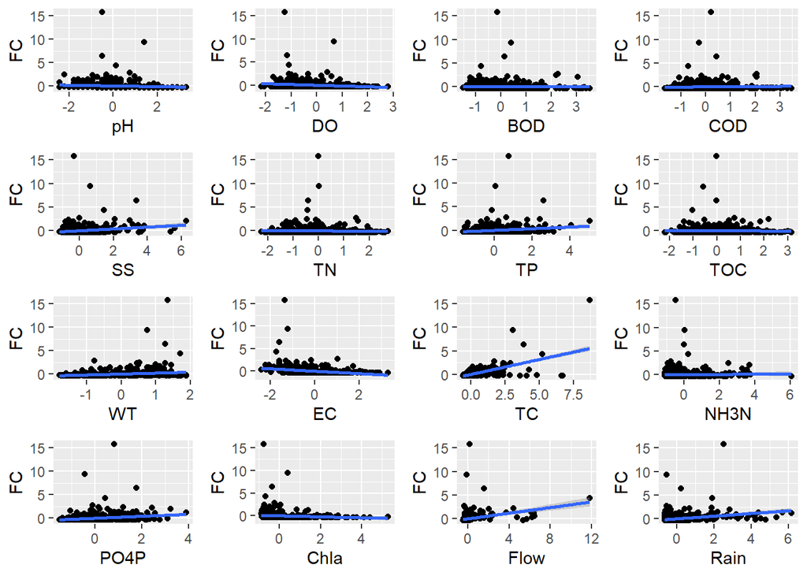

```r
ex2 <- read.csv("C:/Users/HSY/Desktop/우치(2010-2019).csv", sep=",", header=T)
ex2 <- ex2[,-1]
ex2_scale <- scale(ex2)
ex2_scale <- as.data.frame(ex2_scale)
g1 <- ggplot(data=ex2_scale,aes(x=pH,y=FC)) + geom_point() + stat_smooth(method=lm)
g2 <- ggplot(data=ex2_scale,aes(x=DO,y=FC)) + geom_point() + stat_smooth(method=lm)
g3 <- ggplot(data=ex2_scale,aes(x=BOD,y=FC)) + geom_point() + stat_smooth(method=lm)
g4 <- ggplot(data=ex2_scale,aes(x=COD,y=FC)) + geom_point() + stat_smooth(method=lm)
g5 <- ggplot(data=ex2_scale,aes(x=SS,y=FC)) + geom_point() + stat_smooth(method=lm)
g6 <- ggplot(data=ex2_scale,aes(x=TN,y=FC)) + geom_point() + stat_smooth(method=lm)
g7 <- ggplot(data=ex2_scale,aes(x=TP,y=FC)) + geom_point() + stat_smooth(method=lm)
g8 <- ggplot(data=ex2_scale,aes(x=TOC,y=FC)) + geom_point() + stat_smooth(method=lm)
g9 <- ggplot(data=ex2_scale,aes(x=WT,y=FC)) + geom_point() + stat_smooth(method=lm)
g10 <- ggplot(data=ex2_scale,aes(x=EC,y=FC)) + geom_point() + stat_smooth(method=lm)
g11 <- ggplot(data=ex2_scale,aes(x=TC,y=FC)) + geom_point() + stat_smooth(method=lm)
g12 <- ggplot(data=ex2_scale,aes(x=NH3N,y=FC)) + geom_point() + stat_smooth(method=lm)
g13 <- ggplot(data=ex2_scale,aes(x=PO4P,y=FC)) + geom_point() + stat_smooth(method=lm)
g14 <- ggplot(data=ex2_scale,aes(x=Chla,y=FC)) + geom_point() + stat_smooth(method=lm)
g15 <- ggplot(data=ex2_scale,aes(x=Flow,y=FC)) + geom_point() + stat_smooth(method=lm)
g16 <- ggplot(data=ex2_scale,aes(x=Rain,y=FC)) + geom_point() + stat_smooth(method=lm)
grid.arrange(g1,g2,g3,g4,g5,g6,g7,g8,g9,g10,g11,g12,g13,g14,g15,g16,nrow=4,ncol=4)
```

```r
gfit <- lm(FC~.,data=ex2_scale)
summary(gfit) # Adjusted R-squared:  0.3956
```

```
##
## Call:
## lm(formula = FC ~ ., data = ex2_scale)
##
## Residuals:
##     Min      1Q  Median      3Q     Max
## -4.3049 -0.1245  0.0101  0.1133 10.1597
##
## Coefficients:
##               Estimate Std. Error t value Pr(>|t|)
## (Intercept) -1.194e-17  3.439e-02   0.000    1.000
## pH           4.178e-02  4.377e-02   0.954    0.340
## DO           6.809e-02  6.524e-02   1.044    0.297
## BOD         -1.721e-02  7.366e-02  -0.234    0.815
## COD         -2.618e-02  8.843e-02  -0.296    0.767
## SS           7.748e-02  5.815e-02   1.332    0.183
## TN           1.159e-02  5.805e-02   0.200    0.842
## TP          -5.647e-04  6.170e-02  -0.009    0.993
## TOC         -2.737e-02  8.041e-02  -0.340    0.734
## WT           1.260e-01  8.333e-02   1.513    0.131
## EC           5.926e-03  5.052e-02   0.117    0.907
## TC           6.144e-01  4.018e-02  15.292   <2e-16 ***
## NH3N        -3.275e-02  4.405e-02  -0.743    0.458
## PO4P         8.926e-03  5.931e-02   0.151    0.880
## Chla        -1.229e-02  6.426e-02  -0.191    0.848
## Flow        -6.435e-02  4.792e-02  -1.343    0.180
## Rain         7.058e-02  4.830e-02   1.461    0.145
## ---
## Signif. codes:  0 '***' 0.001 '**' 0.01 '*' 0.05 '.' 0.1 ' ' 1
##
## Residual standard error: 0.7774 on 494 degrees of freedom
## Multiple R-squared:  0.4145, Adjusted R-squared:  0.3956
## F-statistic: 21.86 on 16 and 494 DF,  p-value: < 2.2e-16
```

```r
vif(gfit)
```

```
##       pH       DO      BOD      COD       SS       TN       TP      TOC
## 1.616737 3.591133 4.578678 6.597873 2.853263 2.843685 3.212443 5.455980
##       WT       EC       TC     NH3N     PO4P     Chla     Flow     Rain
## 5.859472 2.153188 1.362148 1.637623 2.967658 3.483731 1.937318 1.968099
```

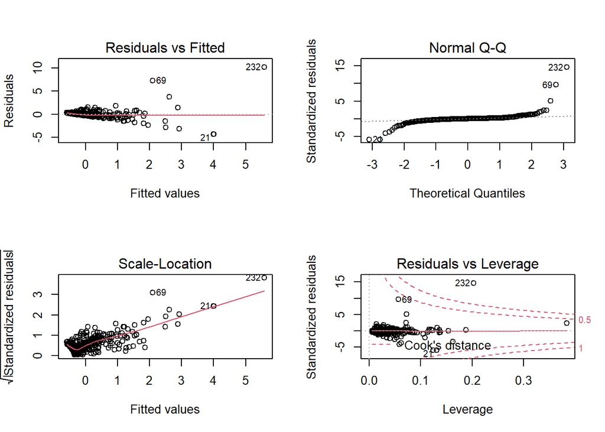

```r
par(mfrow=c(2,2))
plot(gfit)
```

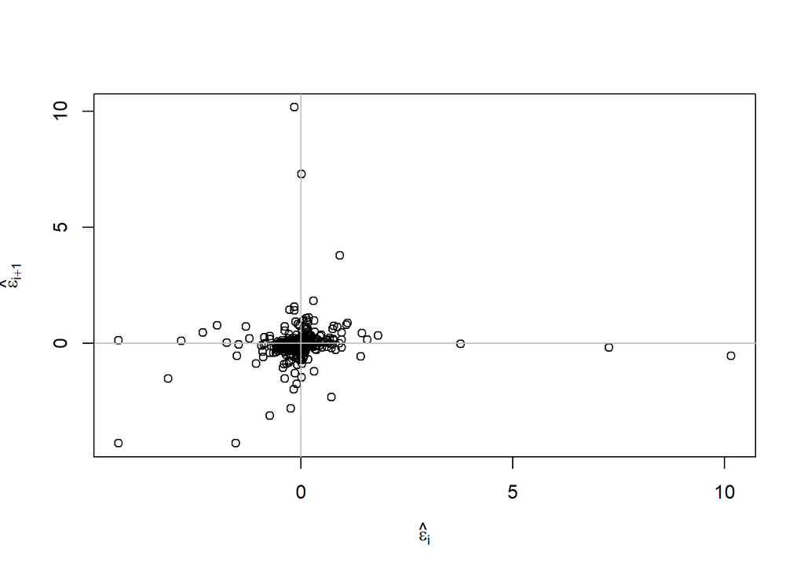

```r
par(mfrow=c(1,1))
n <- length(residuals(gfit))
plot(tail(residuals(gfit),n-1) ~ head(residuals(gfit),n-1), xlab= expression(hat(epsilon)[i]),ylab=expression(hat(epsilon)[i+1]))
abline(h=0,v=0,col=grey(0.75))
```

```r
dwtest(FC~.,data=ex2_scale) # 잔차가 양의 자기상관성을 가지고 있음.
```

```
##
##  Durbin-Watson test
##
## data:  FC ~ .
## DW = 1.7554, p-value = 0.001203
## alternative hypothesis: true autocorrelation is greater than 0
```

```r
gfit1 <- lm(FC~TC,data=ex2_scale) # 모형 gfit에서 유의하지 않은 변수를 제외함.
summary(gfit1) # Adjusted R-squared:  0.3985
```

```
##
## Call:
## lm(formula = FC ~ TC, data = ex2_scale)
##
## Residuals:
##     Min      1Q  Median      3Q     Max
## -4.5518 -0.0918  0.0123  0.0618 10.2298
##
## Coefficients:
##              Estimate Std. Error t value Pr(>|t|)
## (Intercept) 9.852e-18  3.431e-02    0.00        1
## TC          6.322e-01  3.434e-02   18.41   <2e-16 ***
## ---
## Signif. codes:  0 '***' 0.001 '**' 0.01 '*' 0.05 '.' 0.1 ' ' 1
##
## Residual standard error: 0.7756 on 509 degrees of freedom
## Multiple R-squared:  0.3997, Adjusted R-squared:  0.3985
## F-statistic: 338.9 on 1 and 509 DF,  p-value: < 2.2e-16
```

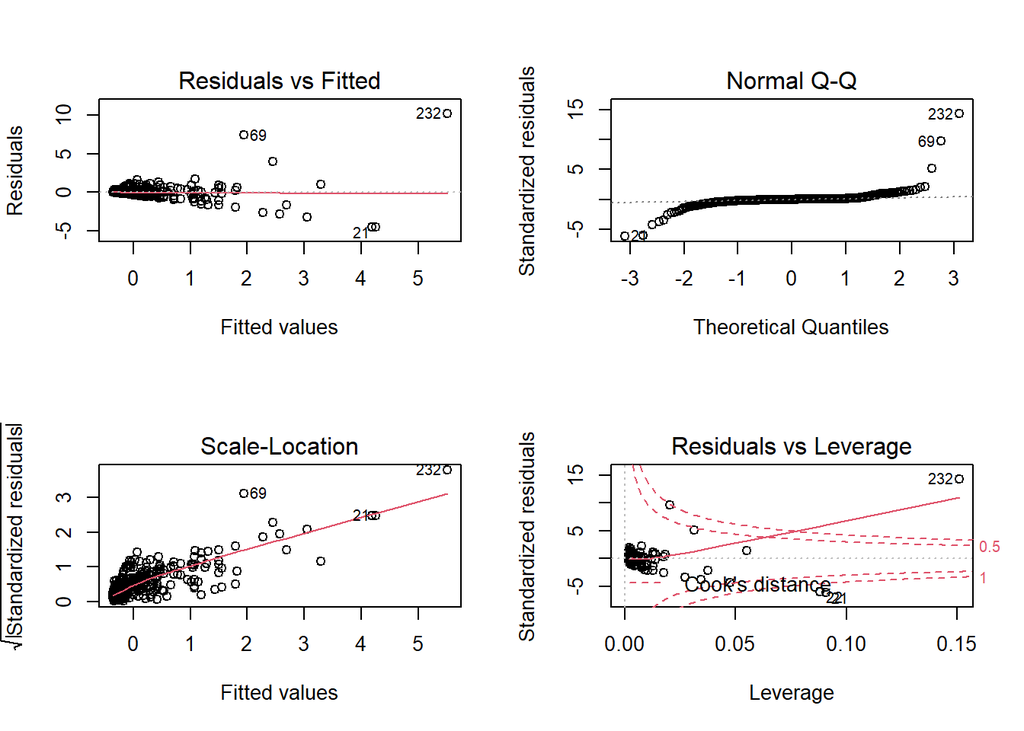

```r
par(mfrow=c(2,2))
plot(gfit1)
```

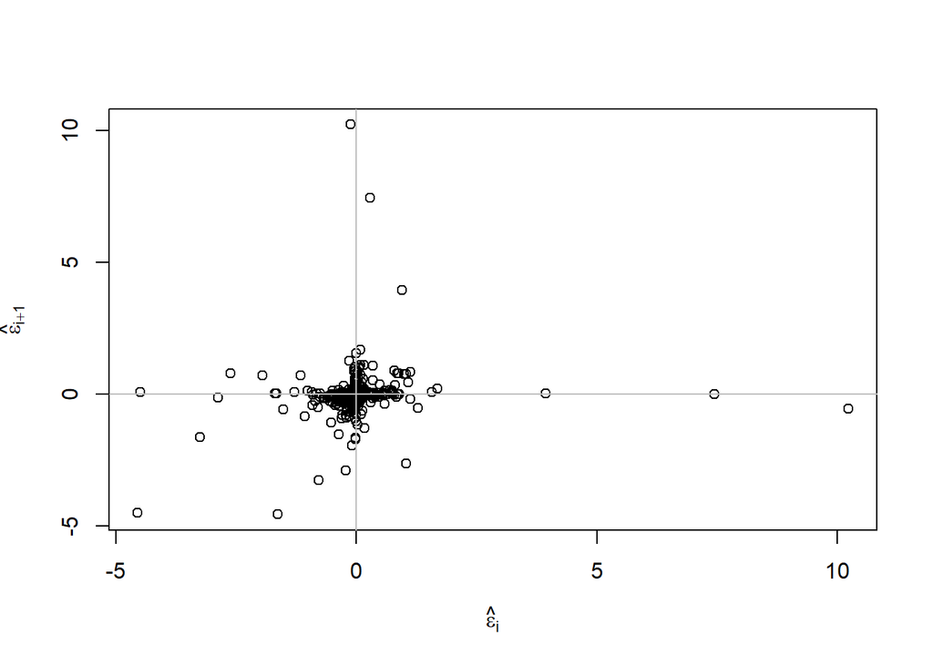

```r
par(mfrow=c(1,1))
n <- length(residuals(gfit1))
plot(tail(residuals(gfit1),n-1) ~ head(residuals(gfit1),n-1), xlab= expression(hat(epsilon)[i]),ylab=expression(hat(epsilon)[i+1]))
abline(h=0,v=0,col=grey(0.75))
```

```r
dwtest(FC~TC,data=ex2_scale)
```

```
##
##  Durbin-Watson test
##
## data:  FC ~ TC
## DW = 1.7258, p-value = 0.0009144
## alternative hypothesis: true autocorrelation is greater than 0
```

```r
# 다중회귀분석에 대한 기본가정인 잔차(residual)에 대한 정규성, 등분산성, 독립성, 선형성 등을 만족하지 못함.
```

### Generalized Additive Model

#### scaling data 사용

```r
mm <- gam(FC~s(pH)+s(DO)+s(BOD)+s(COD)+s(SS)+s(TN)+s(TP)+s(TOC)+s(WT)+s(EC)+s(Chla)+s(NH3N)+s(PO4P)+s(TC)+s(Flow)+s(Rain),data=ex2_scale)
ggGam(mm)
```

```
##  chr "ggGam(model = mm)"
## List of 1
##  $ model: chr "mm"
```

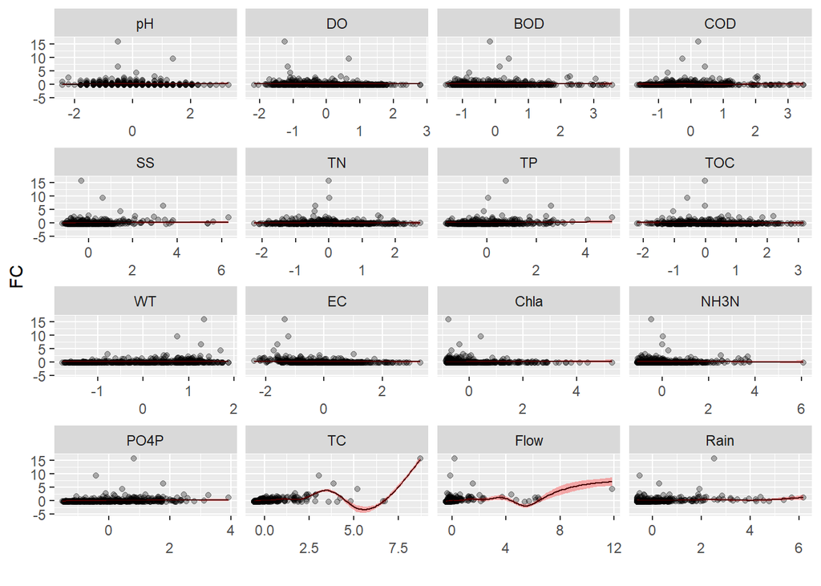

```r
summary(mm) # R-sq.(adj) =  0.773
```

```
##
## Family: gaussian
## Link function: identity
##
## Formula:
## FC ~ s(pH) + s(DO) + s(BOD) + s(COD) + s(SS) + s(TN) + s(TP) +
##     s(TOC) + s(WT) + s(EC) + s(Chla) + s(NH3N) + s(PO4P) + s(TC) +
##     s(Flow) + s(Rain)
##
## Parametric coefficients:
##               Estimate Std. Error t value Pr(>|t|)
## (Intercept) -1.933e-13  2.109e-02       0        1
##
## Approximate significance of smooth terms:
##           edf Ref.df       F p-value
## s(pH)   1.000  1.000   2.425  0.1201
## s(DO)   1.000  1.000   0.024  0.8778
## s(BOD)  1.000  1.000   0.028  0.8680
## s(COD)  5.289  6.400   1.551  0.1492
## s(SS)   1.000  1.000   0.290  0.5905
## s(TN)   4.394  5.447   0.912  0.5086
## s(TP)   2.056  2.632   1.349  0.2915
## s(TOC)  1.000  1.000   0.242  0.6230
## s(WT)   1.000  1.000   0.071  0.7906
## s(EC)   1.000  1.000   0.357  0.5502
## s(Chla) 1.917  2.438   0.990  0.4490
## s(NH3N) 1.651  2.088   0.311  0.7965
## s(PO4P) 1.849  2.346   2.526  0.0780 .
## s(TC)   8.861  8.991 135.339  <2e-16 ***
## s(Flow) 8.645  8.955  14.135  <2e-16 ***
## s(Rain) 5.328  6.426   1.862  0.0734 .
## ---
## Signif. codes:  0 '***' 0.001 '**' 0.01 '*' 0.05 '.' 0.1 ' ' 1
##
## R-sq.(adj) =  0.773   Deviance explained = 79.4%
## GCV = 0.25084  Scale est. = 0.22728   n = 511
```

```r
concurvity(mm,full=TRUE) # 공선성 존재
```

```
##                  para     s(pH)     s(DO)    s(BOD)    s(COD)     s(SS)
## worst    4.784857e-18 0.7729171 0.8300783 0.8616414 0.9164873 0.9762464
## observed 4.784857e-18 0.5783722 0.8130375 0.8490420 0.5163065 0.7960000
## estimate 4.784857e-18 0.5326360 0.7312673 0.7690034 0.8676938 0.6927361
##              s(TN)     s(TP)    s(TOC)     s(WT)     s(EC)   s(Chla)   s(NH3N)
## worst    0.8082328 0.9745293 0.8916866 0.9152258 0.8074389 0.8474375 0.6768679
## observed 0.4595745 0.6582944 0.8777583 0.8995927 0.7416323 0.8305253 0.4504162
## estimate 0.6891451 0.7399790 0.8232780 0.8614165 0.6562029 0.6979339 0.5154502
##            s(PO4P)     s(TC)   s(Flow)   s(Rain)
## worst    0.7929106 0.7851802 0.9006034 0.7825383
## observed 0.7790899 0.3220163 0.6871882 0.6236205
## estimate 0.7106308 0.3885914 0.7574988 0.6705892
```

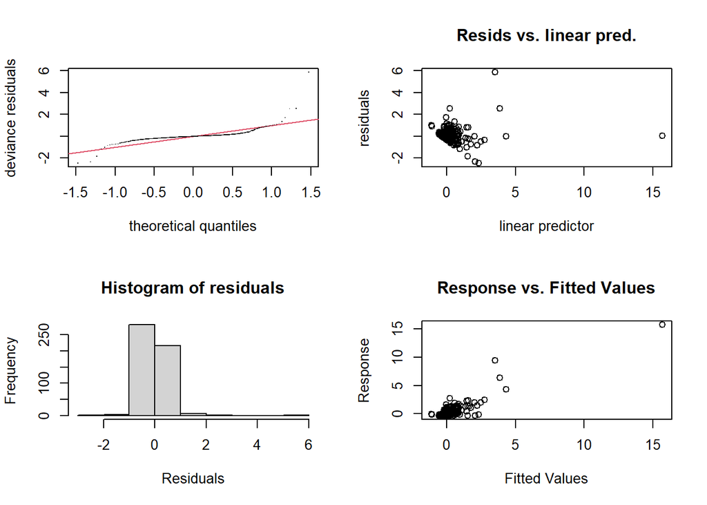

```
##
## Method: GCV   Optimizer: magic
## Smoothing parameter selection converged after 27 iterations.
## The RMS GCV score gradient at convergence was 5.206642e-08 .
## The Hessian was positive definite.
## Model rank =  145 / 145
##
## Basis dimension (k) checking results. Low p-value (k-index<1) may
## indicate that k is too low, especially if edf is close to k'.
##
##           k'  edf k-index p-value
## s(pH)   9.00 1.00    0.96   0.155
## s(DO)   9.00 1.00    1.04   0.870
## s(BOD)  9.00 1.00    0.99   0.310
## s(COD)  9.00 5.29    0.94   0.065 .
## s(SS)   9.00 1.00    0.90   0.010 **
## s(TN)   9.00 4.39    1.01   0.520
## s(TP)   9.00 2.06    1.06   0.935
## s(TOC)  9.00 1.00    1.02   0.680
## s(WT)   9.00 1.00    1.05   0.890
## s(EC)   9.00 1.00    1.00   0.445
## s(Chla) 9.00 1.92    1.00   0.485
## s(NH3N) 9.00 1.65    0.96   0.155
## s(PO4P) 9.00 1.85    0.97   0.230
## s(TC)   9.00 8.86    1.20   1.000
## s(Flow) 9.00 8.65    1.03   0.780
## s(Rain) 9.00 5.33    0.97   0.180
## ---
## Signif. codes:  0 '***' 0.001 '**' 0.01 '*' 0.05 '.' 0.1 ' ' 1
```

```r
par(mfrow=c(2,2))
gam.check(mm) # 적합결여 존재 (기저함수 부족)
```

```r
par(mfrow=c(1,1))
mm1 <- gam(FC~s(TC)+s(Flow),data=ex2_scale) # 모형 mm에서 유의하지 않은 변수를 제외하고 모형구축.
ggGam(mm1)
```

```
##  chr "ggGam(model = mm1)"
## List of 1
##  $ model: chr "mm1"
```

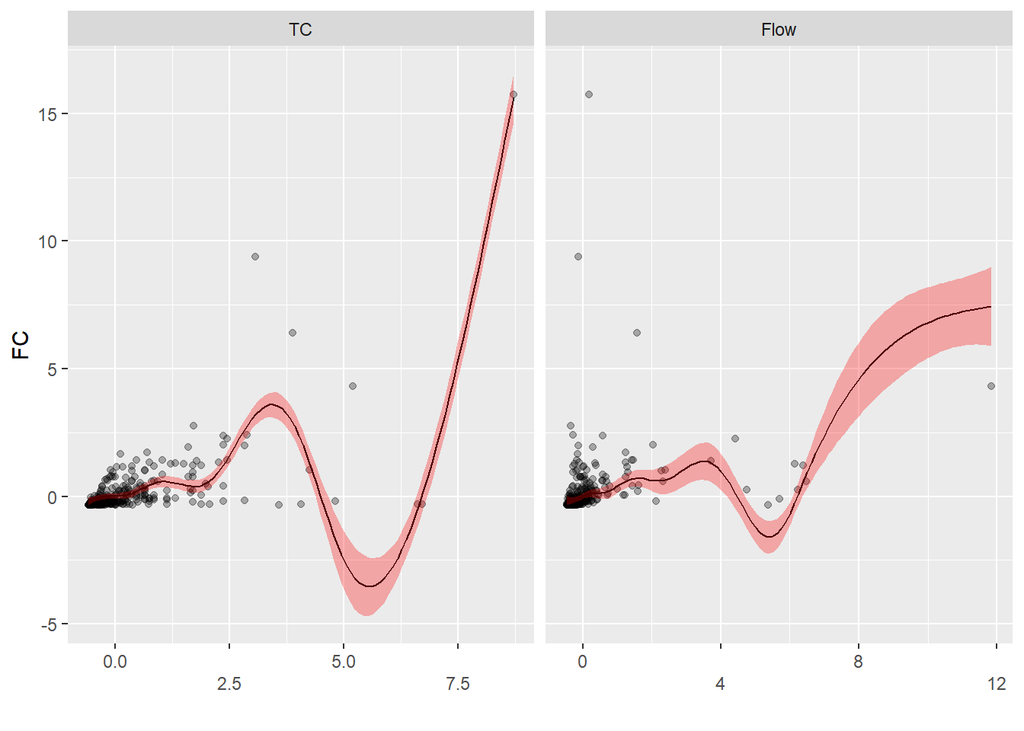

```r
summary(mm1) # R-sq.(adj) =  0.762
```

```
##
## Family: gaussian
## Link function: identity
##
## Formula:
## FC ~ s(TC) + s(Flow)
##
## Parametric coefficients:
##              Estimate Std. Error t value Pr(>|t|)
## (Intercept) 4.367e-15  2.158e-02       0        1
##
## Approximate significance of smooth terms:
##           edf Ref.df      F p-value
## s(TC)   8.853  8.991 140.99  <2e-16 ***
## s(Flow) 8.621  8.955  16.15  <2e-16 ***
## ---
## Signif. codes:  0 '***' 0.001 '**' 0.01 '*' 0.05 '.' 0.1 ' ' 1
##
## R-sq.(adj) =  0.762   Deviance explained =   77%
## GCV = 0.24685  Scale est. = 0.23792   n = 511
```

```r
concurvity(mm1,full=TRUE)
```

```
##                  para     s(TC)   s(Flow)
## worst    9.174455e-24 0.6784270 0.6784270
## observed 9.174455e-24 0.1066415 0.5836386
## estimate 9.174455e-24 0.1707184 0.3793206
```

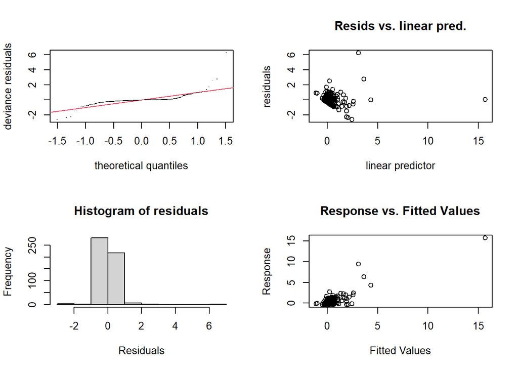

```
##
## Method: GCV   Optimizer: magic
## Smoothing parameter selection converged after 9 iterations.
## The RMS GCV score gradient at convergence was 2.626084e-06 .
## The Hessian was positive definite.
## Model rank =  19 / 19
##
## Basis dimension (k) checking results. Low p-value (k-index<1) may
## indicate that k is too low, especially if edf is close to k'.
##
##           k'  edf k-index p-value
## s(TC)   9.00 8.85    1.23    1.00
## s(Flow) 9.00 8.62    1.04    0.83
```

```r
par(mfrow=c(2,2))
gam.check(mm1)
```

```r
par(mfrow=c(1,1))
```

### Time Varying Coefficient Model

#### scaling data 사용

```r
par(mar=c(4,4,4,4))
par(oma=c(0.5,0.5,0.5,0.5))
nrow(ex2_scale)
```

```
## [1] 511
```

```r
ex2_scale$time <- 1:nrow(ex2_scale)
head(ex2_scale)
```

```
##            pH        DO         BOD        COD         SS       TN          TP
## 1 -0.93716819 1.0893800 -0.58575074 -1.3453204 -1.0140482 1.980445 -0.64266981
## 2 -0.51261770 1.5901355 -1.01304357 -1.2114347 -0.8538304 1.606223 -0.59069477
## 3 -1.36171867 1.2980281  0.34005039 -0.8544060 -0.6592803 1.834562 -0.09693192
## 4 -0.08806722 0.8807319 -0.51453527 -0.7205202 -0.6821685 1.086118 -0.64266981
## 5 -0.08806722 1.2562985 -0.58575074 -0.9882917 -0.7851657 1.046475 -0.69464485
## 6 -0.72489295 1.3814873 -0.08724244 -0.6312631 -0.7165009 1.752106 -0.25285703
##          TOC        WT        EC          TC      NH3N       PO4P       Chla
## 1 -1.3280643 -1.489617 0.5356084 -0.27362350 0.3426390 0.29025953 -0.7228834
## 2 -1.0977628 -1.607883 1.0322439 -0.34948431 0.3791386 0.33192319 -0.7186387
## 3 -1.0401874 -1.607883 0.3742018 -0.22621050 1.8172223 0.91521440 -0.6210099
## 4 -0.5795845 -1.253085 1.0694916 -0.29258870 0.6419356 0.12360490 -0.3620813
## 5 -1.0401874 -1.134820 0.6597673 -0.02707589 0.1674410 0.08194124 -0.7313729
## 6 -0.6947352 -1.489617 0.1134681 -0.23569310 1.0215313 0.79022342 -0.7695755
##           FC       Flow       Rain time
## 1 -0.3032294 -0.3733651 -0.4038260    1
## 2 -0.3254468 -0.3811804 -0.5212748    2
## 3 -0.3024633 -0.3785186 -0.3353142    3
## 4 -0.2733509 -0.3495793 -0.3377611    4
## 5 -0.1894610 -0.3662860 -0.4405288    5
## 6 -0.2162751 -0.2998558  0.4501246    6
```

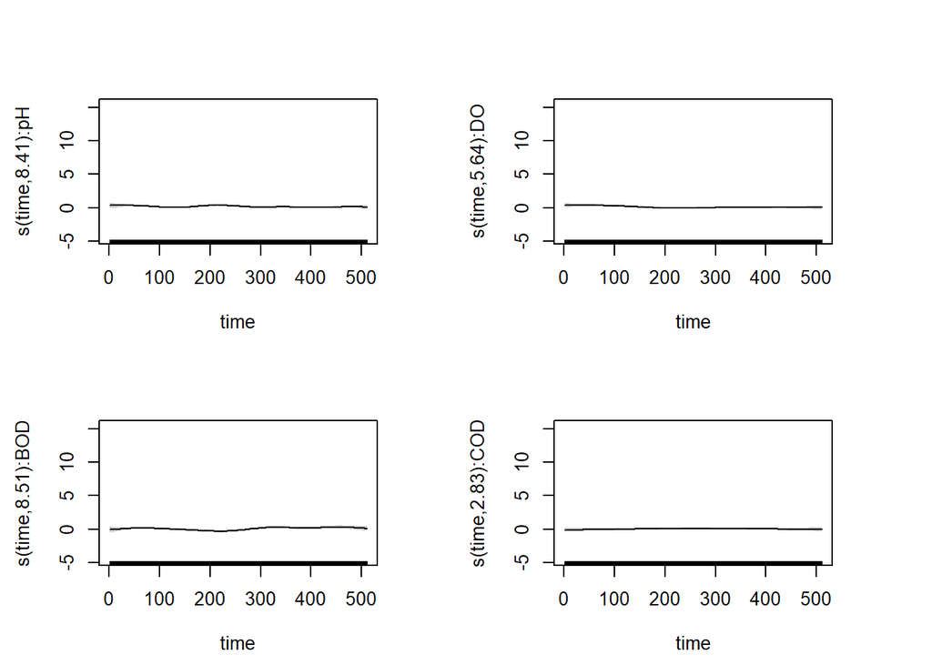

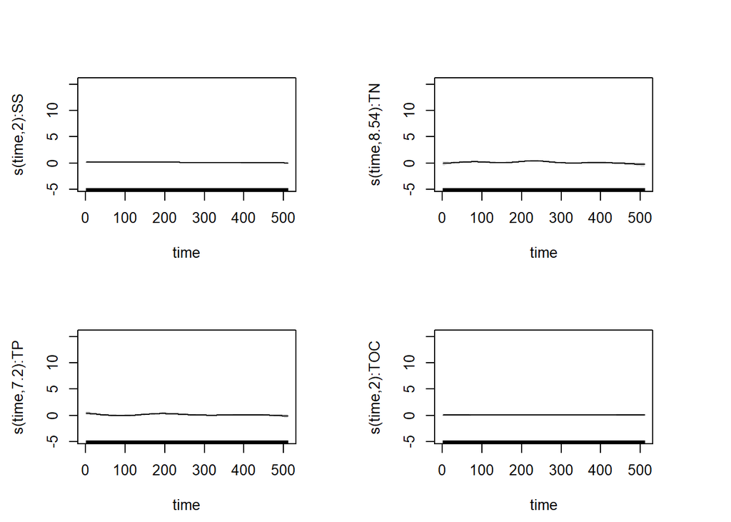

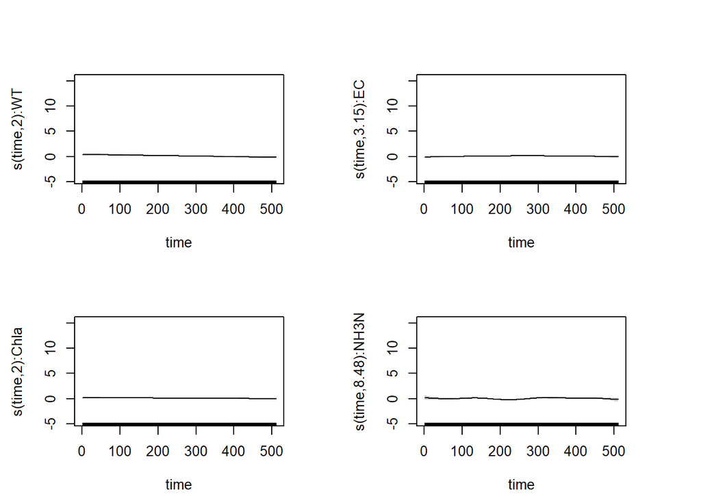

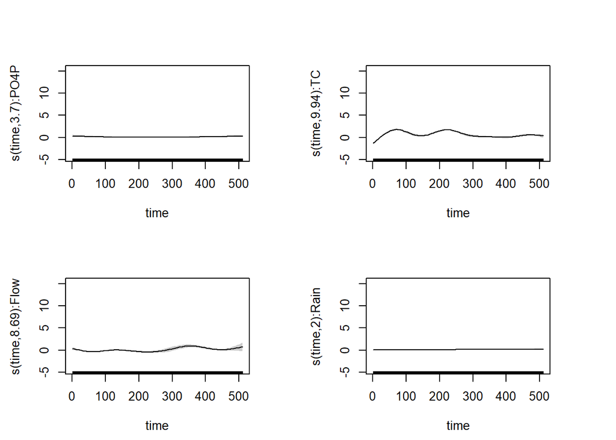

```r
vc1 <- gam(FC~s(time,by=pH)+s(time,by=DO)+s(time,by=BOD)+s(time,by=COD)+s(time,by=SS)+s(time,by=TN)+s(time,by=TP)+s(time,by=TOC)+s(time,by=WT)+s(time,by=EC)+s(time,by=Chla)+s(time,by=NH3N)+s(time,by=PO4P)+s(time,by=TC)+s(time,by=Flow)+s(time,by=Rain),data=ex2_scale)
par(mfrow=c(2,2))
plot(vc1,residuals=TRUE,pch=1,shade=TRUE,seWithMean=TRUE,shift=coef(vc1)[1])
```

```r
par(mfrow=c(1,1))
summary(vc1) # R-sq.(adj) =  0.831
```

```
##
## Family: gaussian
## Link function: identity
##
## Formula:
## FC ~ s(time, by = pH) + s(time, by = DO) + s(time, by = BOD) +
##     s(time, by = COD) + s(time, by = SS) + s(time, by = TN) +
##     s(time, by = TP) + s(time, by = TOC) + s(time, by = WT) +
##     s(time, by = EC) + s(time, by = Chla) + s(time, by = NH3N) +
##     s(time, by = PO4P) + s(time, by = TC) + s(time, by = Flow) +
##     s(time, by = Rain)
##
## Parametric coefficients:
##             Estimate Std. Error t value Pr(>|t|)
## (Intercept)  0.07439    0.02794   2.662  0.00806 **
## ---
## Signif. codes:  0 '***' 0.001 '**' 0.01 '*' 0.05 '.' 0.1 ' ' 1
##
## Approximate significance of smooth terms:
##                edf Ref.df       F p-value
## s(time):pH   8.407  9.314   2.787 0.00288 **
## s(time):DO   5.643  6.604   2.350 0.02194 *
## s(time):BOD  8.511  9.344   2.948 0.00170 **
## s(time):COD  2.829  3.281   1.119 0.35757
## s(time):SS   2.000  2.000   2.478 0.08509 .
## s(time):TN   8.536  9.347   3.246 0.00120 **
## s(time):TP   7.201  8.207   2.010 0.04272 *
## s(time):TOC  2.000  2.000   0.008 0.99226
## s(time):WT   2.000  2.000   4.993 0.00719 **
## s(time):EC   3.149  3.676   1.873 0.11873
## s(time):Chla 2.000  2.000   1.089 0.33751
## s(time):NH3N 8.481  9.317   2.079 0.02746 *
## s(time):PO4P 3.698  4.327   1.560 0.16700
## s(time):TC   9.938  9.994 175.488 < 2e-16 ***
## s(time):Flow 8.688  9.385  13.201 < 2e-16 ***
## s(time):Rain 2.000  2.000   2.121 0.12117
## ---
## Signif. codes:  0 '***' 0.001 '**' 0.01 '*' 0.05 '.' 0.1 ' ' 1
##
## R-sq.(adj) =  0.831   Deviance explained =   86%
## GCV = 0.20274  Scale est. = 0.16859   n = 511
```

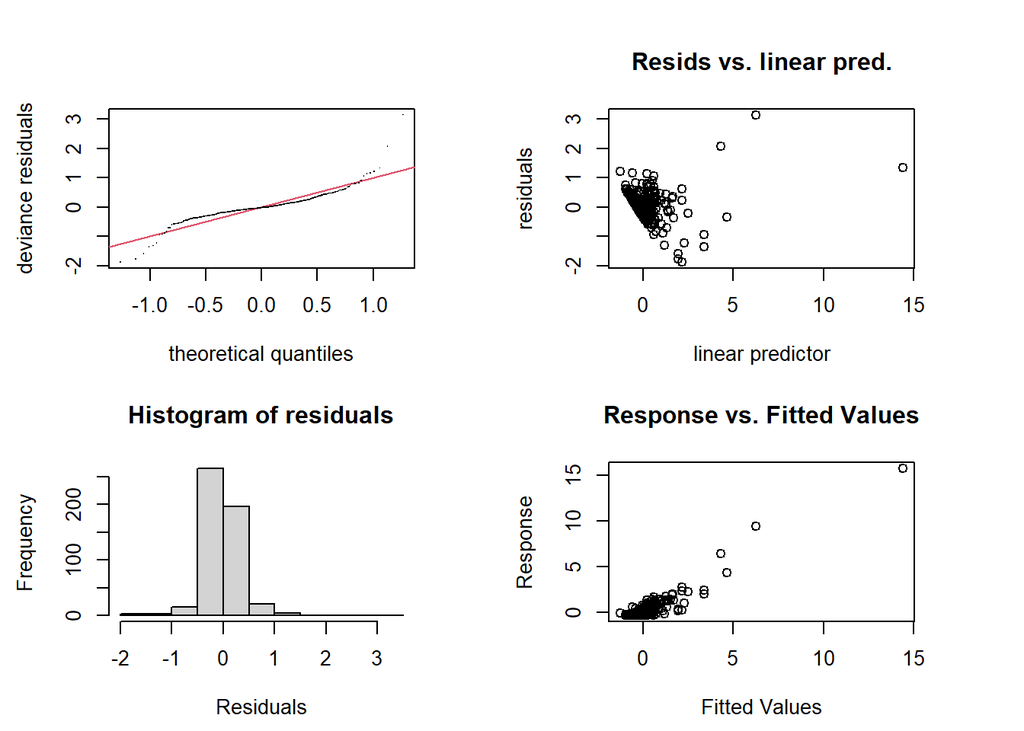

```
##
## Method: GCV   Optimizer: magic
## Smoothing parameter selection converged after 39 iterations.
## The RMS GCV score gradient at convergence was 3.268362e-08 .
## The Hessian was positive definite.
## Model rank =  161 / 161
##
## Basis dimension (k) checking results. Low p-value (k-index<1) may
## indicate that k is too low, especially if edf is close to k'.
##
##                 k'   edf k-index p-value
## s(time):pH   10.00  8.41    1.04    0.81
## s(time):DO   10.00  5.64    1.04    0.78
## s(time):BOD  10.00  8.51    1.04    0.80
## s(time):COD  10.00  2.83    1.04    0.78
## s(time):SS   10.00  2.00    1.04    0.84
## s(time):TN   10.00  8.54    1.04    0.84
## s(time):TP   10.00  7.20    1.04    0.83
## s(time):TOC  10.00  2.00    1.04    0.79
## s(time):WT   10.00  2.00    1.04    0.80
## s(time):EC   10.00  3.15    1.04    0.86
## s(time):Chla 10.00  2.00    1.04    0.82
## s(time):NH3N 10.00  8.48    1.04    0.83
## s(time):PO4P 10.00  3.70    1.04    0.85
## s(time):TC   10.00  9.94    1.04    0.82
## s(time):Flow 10.00  8.69    1.04    0.82
## s(time):Rain 10.00  2.00    1.04    0.81
```

```r
par(mfrow=c(2,2))
gam.check(vc1)
```

```r
par(mfrow=c(1,1))
# vc1 모형에서 유의하지 않은 변수들을 모두 제외할 경우 유의확률에 대한 F 통계량이 발산하게 되어 모형이 적합되지 않으므로 vc1을 최종모형으로 결정함
```

#### 최종선택된 모형의 설명력 : 39.9%(다중선형회귀모형), 76.2%(일반화가법모형), 83.1%(시간에 따른 계수변화모형)

#### 일반화가법모형이나 시간에 따른 계수변화모형이 다중선형회귀모형보다 설명력이 우수하다는 것을 확실하게 보여주기 위해서는 설명변수들과 확실한 비선형관계가 있다고 여겨지는 변수를 반응변수로 선택하는 것이 좋다고 판단됨.